# Data Visualization and Writing Functions Homework

Chris Moroney

2020-10-05

```r
library(tidyverse)
library(openintro)
library(mdsr)
library(readr)
USStates <- read_csv("USStates.csv")
```

### Exercise 1

The following graph shows the relationship between each MLB team’s win percentage and their payroll in hundreds of millions of dollars by year between 2008 and 2014. For each year, we can see in general, according to the loess curve line, there is a very small increase in win percentage as the payroll for each team increases. However, we can see very clearly that not many teams follow the loess curve very closely. There are several teams that have a higher win percentage than what the loess curve shows at that payroll price, while we also see teams that have a much lower win percentage than what the loess line suggests. Additionally, we can see that there are several teams every year that have a lower payroll with a high win percentage. However, we can see that according to the loess curve, there is a very slight increase in win percentage as teams increase their payroll. This suggests that there is a very small chance that a team may win more games if they pay their players more money.

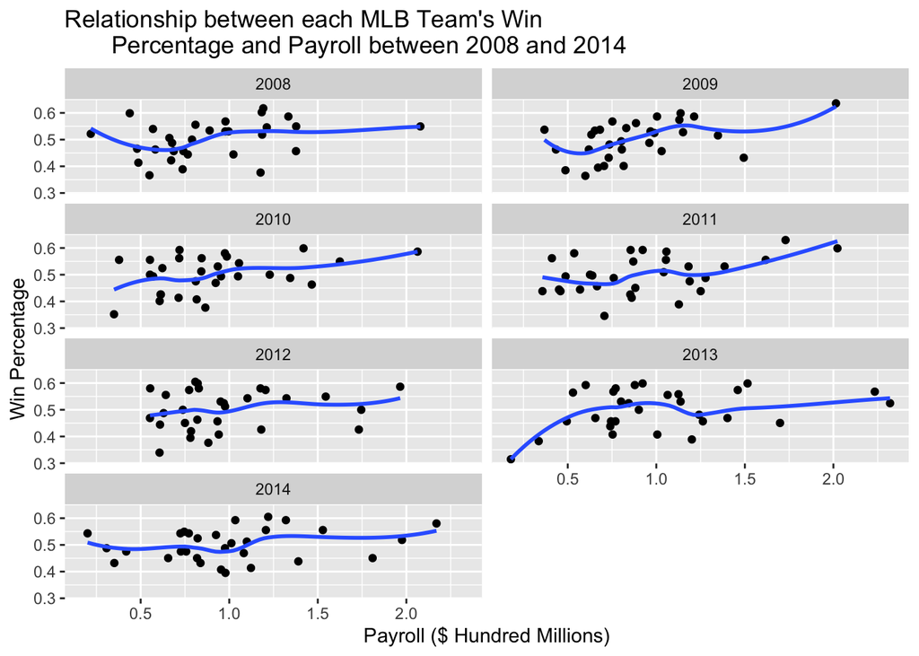

```r
ggplot(data=MLB_teams, mapping=aes(x=payroll / (10^8), y=WPct)) +
  labs(title = "Relationship between each MLB Team's Win
       Percentage and Payroll between 2008 and 2014") +
  labs(x = "Payroll ($ Hundred Millions)") +
  labs(y = "Win Percentage") +
  geom_point() +
  facet_wrap(~ yearID, ncol = 2) +
  geom_smooth(se=FALSE)
```

### Exercise 2

Based off of the patterns in the graph, I can see that in the American League, teams that had a higher Area Population also had a higher Fan Attendance. Additionally, there was a higher payroll for teams with both a higher Area Population and Fan Attendance. Similarly, teams that had a smaller area population also had less fans attending the games. These teams in the American league also did not have as high of a payroll, and a decent number of these teams actually had a lower win percentage as well. In the National League, teams with a higher Fan Attendance generally had a little higher of a Win Percentage compared to teams that had a lower fan attendance. Additionally, the teams with a slightly higher fan attendance generally had a higher payroll. This is similar to the American League, but the Area Population is not as strongly related. The area population seems randomly distributed with no apparent pattern to be seen.

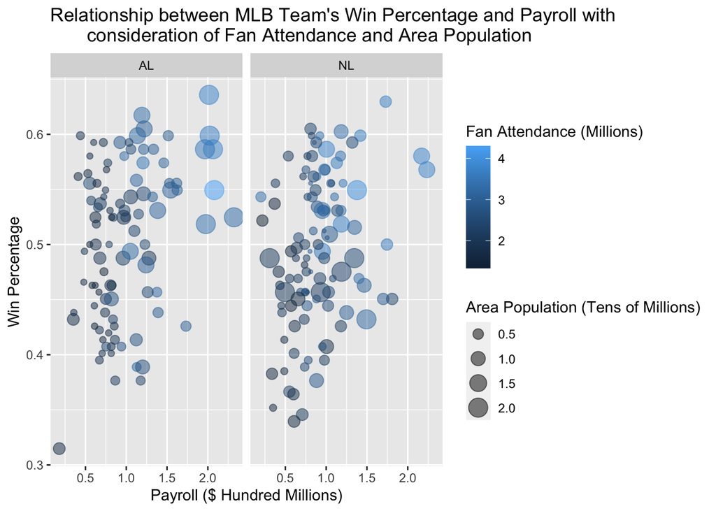

```r
ggplot(data=MLB_teams, mapping=aes(x=payroll / 10^8, y=WPct,
       color=attendance / 10^6, size=metroPop / 10^7)) +
  labs(title = "Relationship between MLB Team's Win Percentage and Payroll with
       consideration of Fan Attendance and Area Population") +
  labs(x = "Payroll ($ Hundred Millions)") +
  labs(y = "Win Percentage") +
  labs(color = "Fan Attendance (Millions)") +
  labs(size = "Area Population (Tens of Millions)") +
  facet_wrap(~ lgID) +
  geom_point(alpha = 0.5)
```

### Exercise 3

```r
mystats <- function(stats){
  structure(list(name = deparse(substitute(stats)),
        mean = mean(stats), sd = sd(stats), min = min(stats),
        Q1 = quantile(stats, 0.25), median = median(stats), Q3 = quantile(stats, 0.75),
        max = max(stats)), class="mystats")
}

print.mystats <- function(x, ...){
    cat("Summary Statistics for ", x$name, ":", "\n",
        "mean = ", x$mean, ", sd = ", x$sd, "\n",
        "Five number summary:", "\n",
        "min = ", x$min, ", Q1 = ", x$Q1, ", median = ", x$median, ", Q3 = ", x$Q3,
        ", max = ", x$max, sep="")
}

mystats(MLB_teams$payroll)
```

```
## Summary Statistics for MLB_teams$payroll:
## mean = 94365324, sd = 40266547
## Five number summary:
## min = 17890700, Q1 = 67325266, median = 85803966, Q3 = 114741109, max = 231978886
```

### Exercise 4

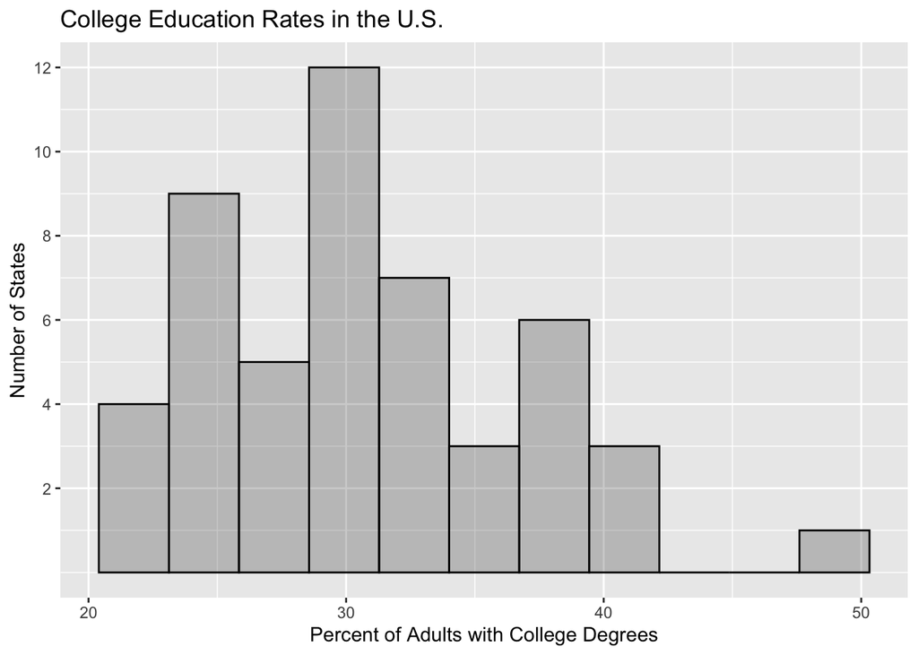

```r
# First Graph
ggplot(data = USStates) +
  labs(title = "College Education Rates in the U.S.") +
  labs(x = "Percent of Adults with College Degrees") +
  labs(y = "Number of States") +
  geom_histogram(mapping=aes(x=College),alpha=0.3,color="black", bins=11)+
  scale_y_continuous(breaks=c(2, 4, 6, 8, 10, 12))
```

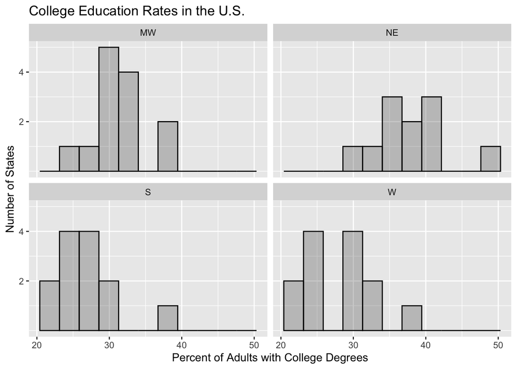

```r
# Second Graph
ggplot(data = USStates) +
  labs(title = "College Education Rates in the U.S.") +
  labs(x = "Percent of Adults with College Degrees") +
  labs(y = "Number of States") +
  geom_histogram(mapping=aes(x=College),alpha=0.3,color="black", bins=11) +
  facet_wrap(~ Region, ncol =2) +
  scale_y_continuous(breaks=c(2, 4, 6, 8, 10, 12))
```

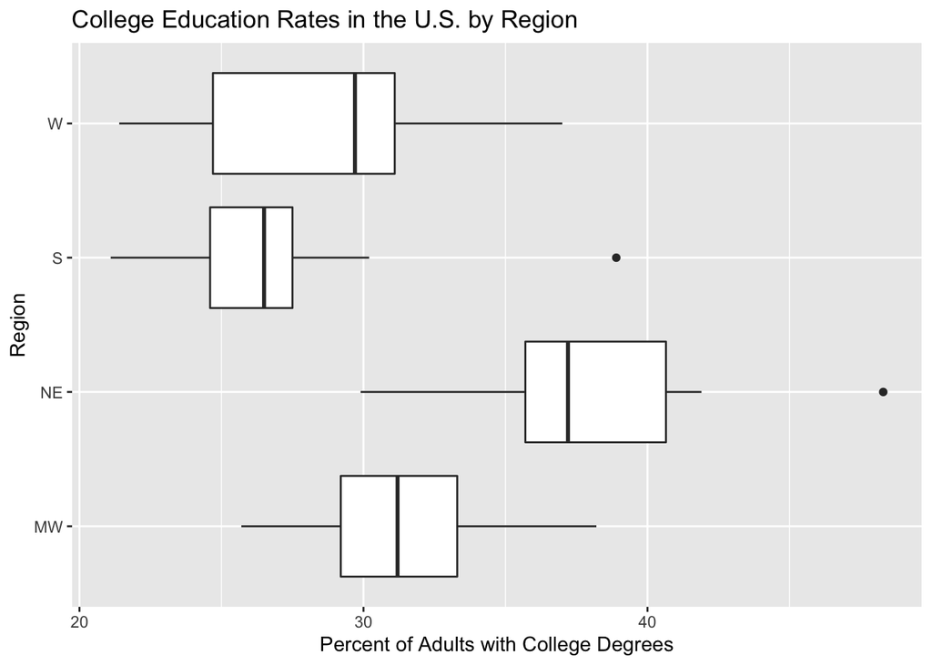

```r
# Third Graph
ggplot(data = USStates) +
  labs(title = "College Education Rates in the U.S. by Region") +
  labs(x = "Percent of Adults with College Degrees") +
  labs(y = "Region") +
  geom_boxplot(mapping = aes(x = College, y = Region)) +
  scale_x_continuous(breaks=c(20, 30, 40, 50))
```

For these graphs, I couldn’t figure out how to:

- Change the definition of bins in order to manipulate the data to fit properly. Could only change the width of the bins as well as the number of bins, but bin definition?
- I could not figure out how to change the order of classes. For instance in the third graph, I couldn’t figure out how to rearrange the graphs to have “NE” first and “W” last.
- I couldn’t figure out entirely why the axis weren’t including all the numbers I desired by tick. I saw in the first two plots, I was being given the y-axis from 2 to 12, but the last plot, I couldn’t get the x-axis to go from 20 to 50.

I prefer the third graph for determining College Degree Percentage by Region. I feel like the box plot allows me to see easier a particular average for each region. We could only tell approximately by groups of how many states in each region had a particular average, but in the box plot, we can tell the college degree graduation by region, which I think is the most beneficial when considering region.

### Exercise 5

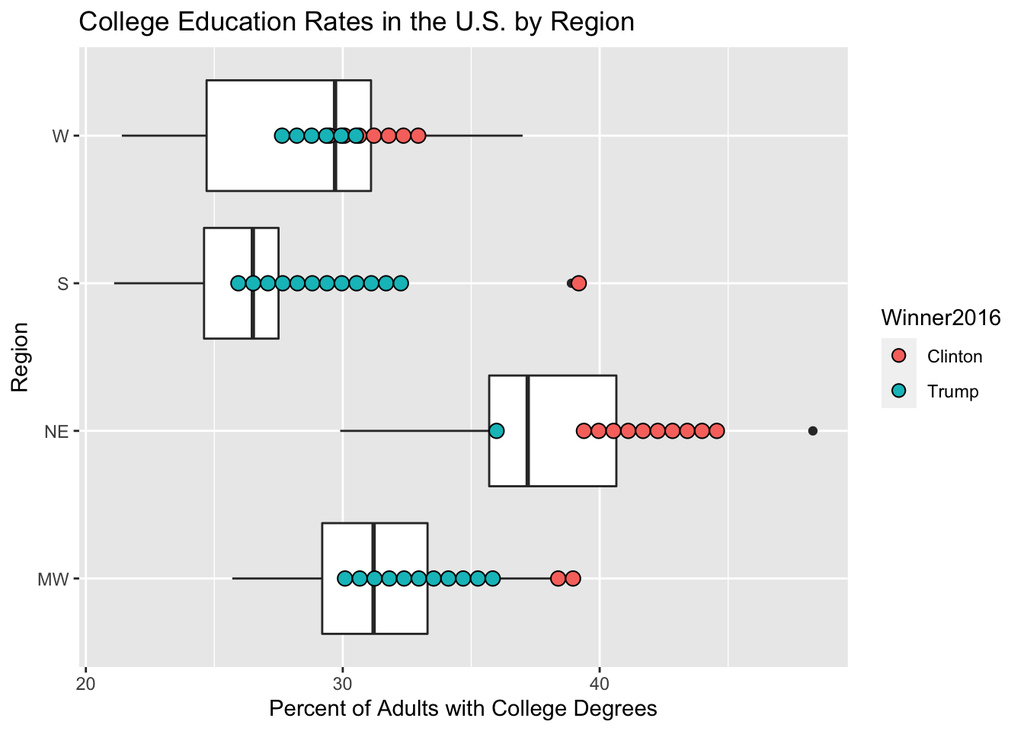

```r
# Attempt at extra, don't understand why my boxplot doesn't work, is WRONG
ggplot(data = USStates, mapping = aes(x = College, y = Region)) +
  labs(title = "College Education Rates in the U.S. by Region") +
  labs(x = "Percent of Adults with College Degrees") +
  labs(y = "Region") +
  geom_boxplot() +
  geom_dotplot(mapping=aes(fill=Winner2016), binaxis="y", stackdir="up", binpositions="all")
```